[figure not shown]

# Part-01 contd..

[figure not shown]

*"VAE" is a type of autoencoder introdued by Diederik P. Kingma, and Max Welling in 2013. In VAE, we can generate realistic images from given random vectors using pre-defined distributions. VAE is different from traditional autoencoders in the following ways:*

- VAE are *probabilistic autoencoders*, i.e., the output generated by the model is determined by pre-defined distribution.
- VAE are *generative autoencoders*, i.e., these are capable of generating new instances similar to the training set.

# VAE Model Architecture

[figure not shown]

Figure 1: VAE (Variational AutoEncoder) Model Architecture[Sourec: https://miro.medium.com/v2/resize:fit:2000/1*c2ECyMArKilDJ5N6dAnZbw.png].

The VAE model is very similar to the autoencoder, consisting of an encoder and decoder. The main difference in the model comes from how the latent space is generated.

$$ \mathcal{VAE_{Loss}} = Recontruction Loss (MSE) + Latent Loss $$

## Latent Loss

Latent loss ($\mathcal{L}$) helps generate the latent space with a similar representation as they are sampled from Gaussian Distribution. For this, purpose, we use KL Diversion Loss (*It measures the divergence of the mean and standard deviation vector from 0 and 1 respectively.* ), and it is mathematically given as follows:

$$ \mathcal{L} = - \frac{1}{2} \sum_{i=0}^{N} 1 + log(\sigma_i^2) - \sigma_i^2 - \mu_i^2 $$

N represents the dimensions of latent space. While $\sigma_i$ and $\mu_i$ are standard deviations and mean values of $\bold \sigma$ and $\bold\mu$ respective vectors. The above equation is tweaked by replacing $\gamma =log(\sigma^2)$ in the above equation. There Latent loss $\mathcal{L}$ can be rewritten as:

$$ \mathcal{L} = - \frac{1}{2} \sum_{i=0}^{N} 1 + \gamma_i - exp(\gamma_i) - \mu_i^2 $$

**Note:** : The network is trained so that mean and standard deviation are centered around 0 and 1, respectively.

```python
#importing Lib.
from torch_snippets import *

import torch
import torchvision
from torch import nn
import torch.nn.functional as F

from torchvision.datasets import FashionMNIST
from torchvision import transforms
from torchsummary import summary
from torchvision.utils import make_grid
from tqdm import tqdm

# seting device - cuda if avaialable
device = 'cuda' if torch.cuda.is_available() else 'cpu'

print(f"Torch version : {torch.__version__} & torchvision version: {torchvision.__version__}, Device is set to '{device}'")
```

```
Torch version : 2.0.1 & torchvision version: 0.15.2, Device is set to 'cuda'
```

## Fatching Data

```python
# defining transformatons for images
img_transform = transforms.Compose([transforms.ToTensor(), # convert image to tensor
                                    transforms.Normalize([0.5], [0.5]), # normalizing image with mean 0.5 and std 0.5
                                    transforms.Lambda(lambda x: x.to(device)) # loading data on GPU
                                    ])

# create training and validation dataset (ds) - downloading and saving dataset in "data/content" folder
train_ds = FashionMNIST('data/content', transform = img_transform, train=True, download=True)
val_ds = FashionMNIST('data/content', transform = img_transform, train=False, download=True)

# defining dataloaders:
BATCH_SIZE = 128
train_dl = DataLoader(train_ds, batch_size=BATCH_SIZE, shuffle=True)
val_dl = DataLoader(val_ds, batch_size=BATCH_SIZE, shuffle=False)
```

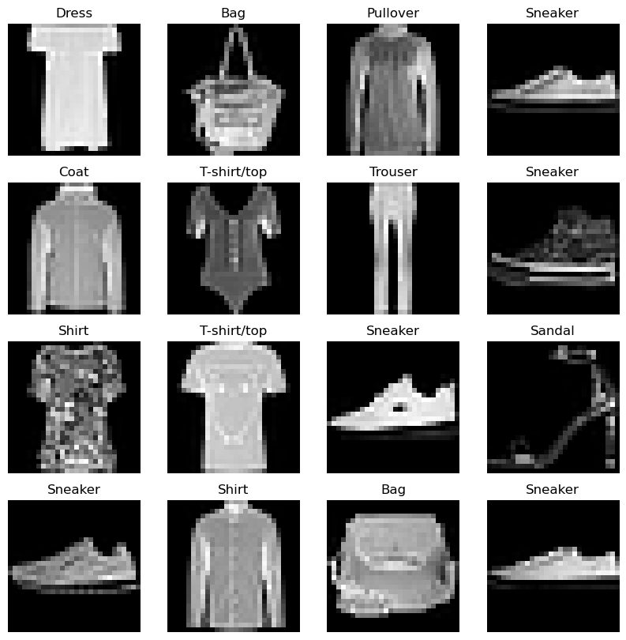

```python
# visualize data
fig = plt.figure(figsize=(10,10))
rows, cols = (4,4)
for i in range(1, rows*cols +1):
    random_idx = torch.randint(0, len(train_ds), size=[1]).item()
    img, label = train_ds[random_idx]
    fig.add_subplot(rows, cols, i)
    plt.imshow(img.cpu().squeeze(), cmap="gray")
    plt.title(train_ds.classes[label])
    plt.axis(False)
```

## VAE Model

```python
class VAE(nn.Module):
    """
    Vanila Autoencoder Model - for 28*28 - gray images
    Inputs- x_dim:int - input dimensions
            h_dim1:int - output dimensions encoder hidden layer 1
            h_dim2:int - output dimensions encoder hidden layer 2
            z_dim:int -  dimesion of latent space
    """
    def __init__(self, x_dim:int, h_dim1:int, h_dim2:int, z_dim:int):
        super(VAE, self).__init__()

        # defining variational arch.
        # defining two layers ENCODER
        self.d1 = nn.Linear(x_dim,h_dim1)
        self.d2 = nn.Linear(h_dim1,h_dim2)

        # defining Mean layer
        self.d31 = nn.Linear(h_dim2,z_dim)

        # defining std layer
        self.d32 = nn.Linear(h_dim2,z_dim)

        # defining two layer DECODER
        self.d4 = nn.Linear(z_dim, h_dim2)
        self.d5 = nn.Linear(h_dim2, h_dim1)

        # final ouput of decoder
        self.d6 = nn.Linear(h_dim1, x_dim)

    # ENCODER METHOD
    def encoder(self,  x:torch.Tensor):
        h = F.relu(self.d1(x))
        h = F.relu(self.d2(h))
        return self.d31(h), self.d32(h)

    # SAMPLING METHOD
    def sampling(self, mean:torch.Tensor, log_var:torch.Tensor):
        std = torch.exp(0.5*log_var)
        noise = torch.rand_like(std)
        return noise.mul(std).add_(mean)

    # DECODER METHOD
    def decoder(self, z:torch.Tensor):
        h = F.relu(self.d4(z))
        h = F.relu(self.d5(h))
        return F.sigmoid(self.d6(h))

    # defining forward pass
    def forward(self, x:torch.Tensor):
        x = x.view(len(x),-1)
        mean, log_var = self.encoder(x)
        z = self.sampling(mean, log_var)

        return self.decoder(z), mean, log_var

# checking Autoecoder Model Architecture
model = VAE(x_dim=784,h_dim1=512,h_dim2=256,z_dim=50).to(device)
print(summary(model, torch.zeros(2,1,28,28)))
```

```
==========================================================================================
Layer (type:depth-idx)                   Output Shape              Param #
==========================================================================================
├─Linear: 1-1                            [-1, 512]                 401,920
├─Linear: 1-2                            [-1, 256]                 131,328
├─Linear: 1-3                            [-1, 50]                  12,850
├─Linear: 1-4                            [-1, 50]                  12,850
├─Linear: 1-5                            [-1, 256]                 13,056
├─Linear: 1-6                            [-1, 512]                 131,584
├─Linear: 1-7                            [-1, 784]                 402,192
==========================================================================================
Total params: 1,105,780
Trainable params: 1,105,780
Non-trainable params: 0
Total mult-adds (M): 1.10
==========================================================================================
Input size (MB): 0.01
Forward/backward pass size (MB): 0.02
Params size (MB): 4.22
Estimated Total Size (MB): 4.24
==========================================================================================
```

[output not shown]

## Training/ validating Loop & Loss Function & Training

```
EPOCH: 1.000  val_kld: 317.176  train_mean: -0.006  train_log_var: -0.053  val_log_var: -0.079  train_recon: 64283.878  val_mean: -0.006  val_loss: 61982.090  train_kld: 404.173  train_loss: 64688.051  val_recon: 61664.914  (33.49s - 636.23s remaining)
```

```
Iamges Generated by VAE after 1 Epochs.
```

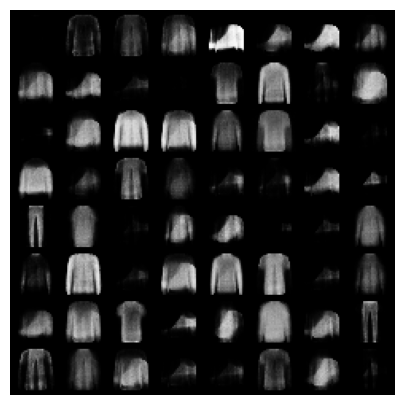

```
EPOCH: 2.000  val_kld: 349.670  train_mean: -0.007  train_log_var: -0.091  val_log_var: -0.094  train_recon: 61409.295  val_mean: -0.004  val_loss: 60567.953  train_kld: 331.843  train_loss: 61741.139  val_recon: 60218.284  (73.25s - 659.27s remaining)
```

```
Iamges Generated by VAE after 2 Epochs.
```

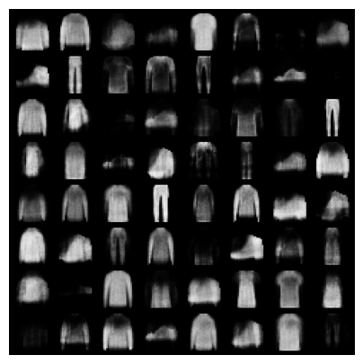

```
EPOCH: 3.000  val_kld: 360.877  train_mean: -0.003  train_log_var: -0.099  val_log_var: -0.100  train_recon: 60881.968  val_mean: 0.005  val_loss: 60187.872  train_kld: 355.687  train_loss: 61237.655  val_recon: 59826.995  (112.07s - 635.06s remaining)
```

```
Iamges Generated by VAE after 3 Epochs.
```

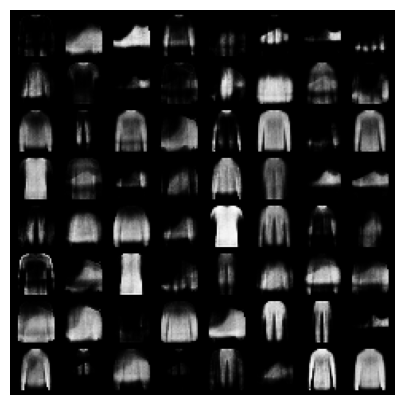

```
EPOCH: 4.000  val_kld: 360.521  train_mean: -0.001  train_log_var: -0.106  val_log_var: -0.104  train_recon: 60545.374  val_mean: 0.006  val_loss: 59938.245  train_kld: 372.873  train_loss: 60918.246  val_recon: 59577.724  (150.34s - 601.35s remaining)
```

```
Iamges Generated by VAE after 4 Epochs.
```

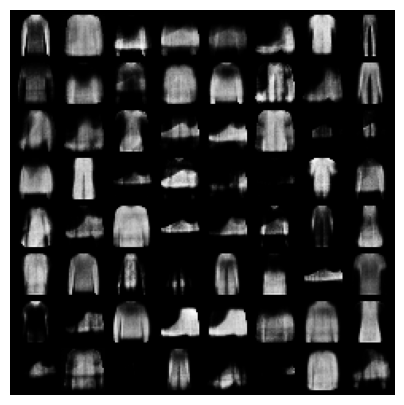

```
EPOCH: 5.000  val_kld: 387.390  train_mean: -0.001  train_log_var: -0.111  val_log_var: -0.109  train_recon: 60316.689  val_mean: 0.003  val_loss: 59781.593  train_kld: 388.222  train_loss: 60704.910  val_recon: 59394.202  (188.40s - 565.20s remaining)
```

```
Iamges Generated by VAE after 5 Epochs.
```

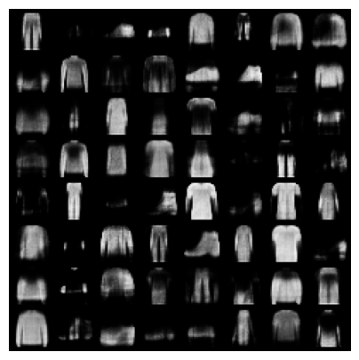

```
EPOCH: 6.000  val_kld: 399.028  train_mean: -0.001  train_log_var: -0.115  val_log_var: -0.121  train_recon: 60188.739  val_mean: -0.003  val_loss: 59656.031  train_kld: 397.696  train_loss: 60586.435  val_recon: 59257.004  (225.88s - 527.06s remaining)
```

```
Iamges Generated by VAE after 6 Epochs.
```

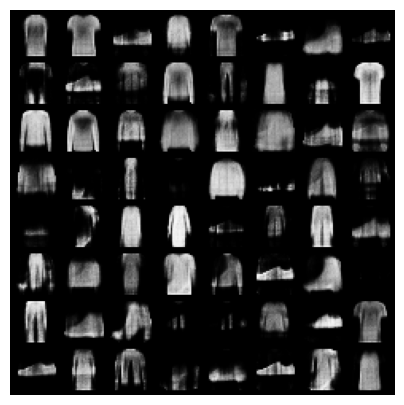

```
EPOCH: 7.000  val_kld: 403.840  train_mean: -0.002  train_log_var: -0.119  val_log_var: -0.113  train_recon: 60087.567  val_mean: 0.003  val_loss: 59597.612  train_kld: 406.682  train_loss: 60494.250  val_recon: 59193.773  (263.63s - 489.60s remaining)
```

```
Iamges Generated by VAE after 7 Epochs.
```

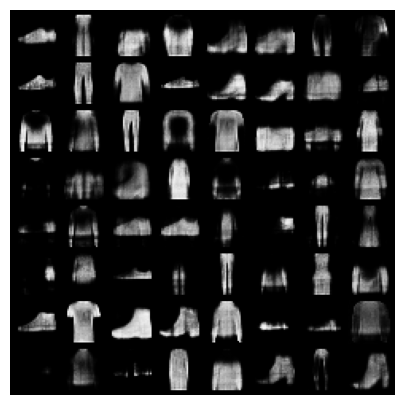

```
EPOCH: 8.000  val_kld: 407.431  train_mean: -0.002  train_log_var: -0.122  val_log_var: -0.127  train_recon: 60003.689  val_mean: -0.004  val_loss: 59535.323  train_kld: 415.075  train_loss: 60418.765  val_recon: 59127.892  (301.22s - 451.83s remaining)
```

```
Iamges Generated by VAE after 8 Epochs.
```

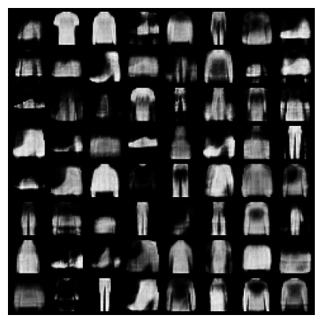

```
EPOCH: 9.000  val_kld: 413.678  train_mean: -0.003  train_log_var: -0.123  val_log_var: -0.122  train_recon: 59933.498  val_mean: -0.006  val_loss: 59473.470  train_kld: 419.626  train_loss: 60353.124  val_recon: 59059.792  (339.03s - 414.37s remaining)
```

```
Iamges Generated by VAE after 9 Epochs.
```

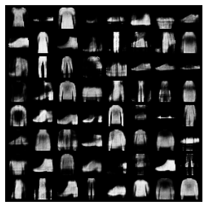

```
EPOCH: 10.000  val_kld: 424.626  train_mean: -0.002  train_log_var: -0.126  val_log_var: -0.127  train_recon: 59874.746  val_mean: -0.003  val_loss: 59414.506  train_kld: 425.495  train_loss: 60300.241  val_recon: 58989.881  (377.82s - 377.82s remaining)
```

```
Iamges Generated by VAE after 10 Epochs.
```

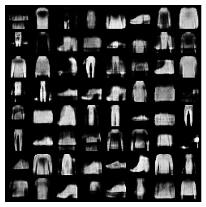

```
EPOCH: 11.000  val_kld: 426.674  train_mean: -0.002  train_log_var: -0.127  val_log_var: -0.125  train_recon: 59827.067  val_mean: 0.005  val_loss: 59382.430  train_kld: 428.440  train_loss: 60255.506  val_recon: 58955.756  (415.69s - 340.11s remaining)
```

```
Iamges Generated by VAE after 11 Epochs.
```

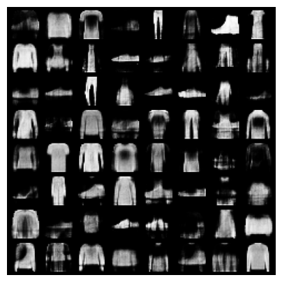

```
EPOCH: 12.000  val_kld: 425.704  train_mean: -0.002  train_log_var: -0.128  val_log_var: -0.135  train_recon: 59778.818  val_mean: -0.002  val_loss: 59336.048  train_kld: 430.463  train_loss: 60209.282  val_recon: 58910.344  (453.72s - 302.48s remaining)
```

```
Iamges Generated by VAE after 12 Epochs.
```

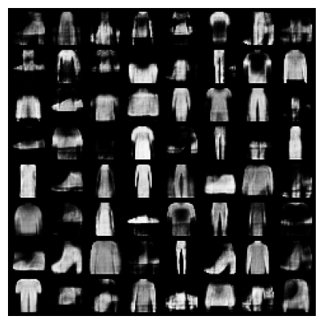

```
EPOCH: 13.000  val_kld: 420.209  train_mean: -0.002  train_log_var: -0.129  val_log_var: -0.121  train_recon: 59737.920  val_mean: -0.003  val_loss: 59311.618  train_kld: 434.918  train_loss: 60172.838  val_recon: 58891.408  (491.59s - 264.70s remaining)
```

```
Iamges Generated by VAE after 13 Epochs.
```

[9 more figures not shown]

```python
# defining the function  for training loop
def train_batch (inp_data:torch.Tensor, model: torch.nn.Module,
                loss_fn: torch.nn.Module,
                optimizer: torch.optim.Optimizer,):
    """
    Training Loop
    """
    model.train()
    data =inp_data.to(device)
    optimizer.zero_grad()
    recon_batch, mean, log_var = model(data)
    loss, mse, kld = loss_fn(recon_batch, data, mean, log_var)
    loss.backward()
    optimizer.step()
    return loss, mse, kld, log_var.mean(), mean.mean()

# defining the validation step
@torch.no_grad()
def val_batch(inp_data:torch.Tensor, model: torch.nn.Module,
                loss_fn: torch.nn.Module):
    """
    Validation Loop
    """
    model.eval()
    data = inp_data.to(device)

    recon_batch, mean, log_var = model(data)
    loss, mse, kld = loss_fn(recon_batch, data, mean, log_var)
    return loss, mse, kld, log_var.mean(), mean.mean()

# defining Criterion(Loss_functions) and optimizer
def loss_fn(recon_x, x, mean, log_var):
    RECON = F.mse_loss(recon_x,x.view(-1,784), reduction='sum')
    KLD = -0.5 * torch.sum(1+log_var-mean.pow(2)-log_var.exp())
    return RECON+KLD, RECON, KLD

optimizer = torch.optim.AdamW(model.parameters(), lr = 1e-3, weight_decay=1e-5)

# define num_epochs

num_epochs = 20
log = Report(num_epochs)



for epoch in range(num_epochs):
    N = len(train_dl)
    for ix, (data, _) in enumerate(train_dl):
        loss, recon, kld, log_var, mean = train_batch(data,model,loss_fn,optimizer)
        pos = epoch+(1+ix)/N
        log.record(pos =pos, train_loss = loss, train_recon =recon, train_kld = kld, train_mean = mean, train_log_var = log_var,  end='\r')

    N = len(val_dl)
    for ix, (data, _) in enumerate(val_dl):
        loss, recon, kld, log_var, mean = val_batch(data,model,loss_fn)
        pos = epoch+(1+ix)/N
        log.record(pos =pos, val_loss = loss, val_recon =recon, val_kld = kld, val_mean = mean, val_log_var = log_var,  end='\r')

    log.report_avgs(epoch+1)

    # VAE results
    print(f"Iamges Generated by VAE after {epoch+1} Epochs.")
    with torch.no_grad():
        z = torch.randn(64,50).to(device)
        sample = model.decoder(z).to(device)
        images = make_grid(sample.view(64,1,28,28)).permute(1,2,0)
        show(images)

log.plot_epochs(['train_loss','val_loss'])
```